# CMSC/LING/STAT 208: ML - Mid-Term Exam

Jo Dang

### **CAUTION**: The tasks in this exam might take time to execute. Please be patient.

## Question 1

This question concerns the KNN technique.

1. Why would one want to standardize predictor variables (considering $p>1$) before using them in a KNN technique?

```
Because when p>1, their values are on different scales. For example, one variable could have values that are x out of 10, while another could have values that are y out of 100. We need to scale the variables so that they are all on the same scale and be comparable to each other. Then, the Euclidean distance, which is what we use when finding neighbors with knn, is not dominated by the variables that have large values.
```

2. Is large $K$ or small $K$ associated with high model variance? Is large $K$ or small $K$ associated with high bias? Explain your answers.

```
Small k is associated with high model variance and large k is associated with high bias. Because as k increases, our model gets less flexible and more stable, which means that bias increases and variance decreases.
```

3. Consider the dataset below.

| Obs. | $Y$ | $X$ |
| --- | --- | --- |
| 1 | A | 1.0 |
| 2 | A | 1.8 |
| 3 | B | 3.2 |
| 4 | A | 4 |
| 5 | B | 5 |
| 6 | B | 5.8 |

Recall that the Euclidean distance between two $p$-dimensional vectors $\mathbf{a}=(a_1, a_2, \ldots, a_p)$ and $\mathbf{b}=(b_1, b_2, \ldots, b_p)$ is

$$||\mathbf{a}-\mathbf{b}||_2 =
\sqrt{(a_1-b_1)^2 + (a_2-b_2)^2 + \ldots + (a_p-b_p)^2}$$

- Consider $K=3$. Predict the class for a test data point with $X=3.7$. Explain your steps.
- Now consider $K=1$. Predict the class for a test data point with $X=4.5$. Explain your steps.
- Explain why standardization is not necessary for the dataset above.

```
- In this case, we will find the responses of the 3 data points that have the shortest Euclidean distances to our test data point X=3.7. These 3 data points are X=3.2, X=4, and X=5. The responses of these 3 data points, respectively, are B, A, B. Then, as response "B" is the majority, I will predict that the response for our test data point is B.

- In this case, we start with finding the response of the 1 data point that has the shortest Euclidean distance to our test data point X=4.5. However, in this case, there are actually 2 data points that have the same Euclidean distances to our test. In other words, they tie. Then, we will take the responses of both points.

These 2 data points are X=4, and X=5. The responses of these 2 data points, respectively, are A and B. Since there is no response that is the majority, the response of our test data point is predicted to be 50% A and 50% B.

- Standardization is not necessary here because there is only 1 p so the values of our explanatory variable is only on 1 scale. Then, the Euclidean distances that we need to calculate is not dominated by unusually large values.
```

## Question 2

For this question, you will work with the **sales.rds** dataset which contains information on the sales of child car seats at 400 different stores. Load the dataset into your R session using the following code.

```r
sales <- readRDS("sales.rds")
```

The dataset contains the following variables.

- `Sales` - Unit sales (in thousands) at each location
- `CompPrice` - Price charged by competitor at each location
- `Income` - Community income level (in thousands of dollars)
- `Advertising` - Local advertising budget for company at each location (in thousands of dollars)
- `Population` - Population size in region (in thousands)
- `Price` - Price company charges for car seats at each site
- `ShelveLoc` - Quality of the shelving location for the car seats at each site (‘Bad’, ‘Medium’, ‘Good’)
- `Age` - Average age of the local population
- `Education` - Education level at each location
- `Urban` - Is the store in an urban or rural location? (‘Yes’, ‘No’)
- `US` - Is the store in the US or not? (‘Yes’, ‘No’)

Consider `Sales` as the response variable and the rest of the variables as predictors.

Compare the performance (in terms of **RMSE**) of the following two models:

- A linear regression model;
- A $K$-NN regression model with optimal $K$ chosen by CV. Consider the grid of possible $K$ values given below.

**Perform the following tasks.**

- Investigate the dataset and complete any necessary tasks. **Write a brief description of your findings.**

```r
glimpse(sales)
```

```
## Rows: 400
## Columns: 11
## $ Sales       <dbl> 9.50, 11.22, 10.06, 7.40, 4.15, 10.81, 6.63, 11.85, 6.54, …
## $ CompPrice   <dbl> 138, 111, 113, 117, 141, 124, 115, 136, 132, 132, 121, 117…
## $ Income      <dbl> 73, 48, 35, 100, 64, 113, 105, 81, 110, 113, 78, 94, 35, 2…
## $ Advertising <dbl> 11, 16, 10, 4, 3, 13, 0, 15, 0, 0, 9, 4, 2, 11, 11, 5, 0, …
## $ Population  <dbl> 276, 260, 269, 466, 340, 501, 45, 425, 108, 131, 150, 503,…
## $ Price       <dbl> 120, 83, 80, 97, 128, 72, 108, 120, 124, 124, 100, 94, 136…
## $ ShelveLoc   <fct> NA, Good, Medium, Medium, Bad, Bad, Medium, Good, Medium, …
## $ Age         <dbl> 42, 65, 59, NA, 38, 78, 71, 67, NA, 76, 26, 50, 62, 53, 52…
## $ Education   <dbl> 17, 10, 12, 14, 13, 16, 15, 10, 10, 17, 10, 13, 18, 18, 18…
## $ Urban       <fct> Yes, Yes, Yes, Yes, Yes, No, Yes, Yes, No, No, No, Yes, Ye…
## $ US          <fct> Yes, Yes, Yes, Yes, No, Yes, No, Yes, No, Yes, Yes, Yes, N…
```

```r
sum(is.na(sales))
```

```
## [1] 170
```

```r
summary(sales)
```

```
##      Sales          CompPrice       Income        Advertising
##  Min.   : 0.000   Min.   : 77   Min.   : 21.00   Min.   : 0.000
##  1st Qu.: 5.390   1st Qu.:115   1st Qu.: 42.75   1st Qu.: 0.000
##  Median : 7.490   Median :125   Median : 69.00   Median : 5.000
##  Mean   : 7.496   Mean   :125   Mean   : 68.66   Mean   : 6.635
##  3rd Qu.: 9.320   3rd Qu.:135   3rd Qu.: 91.00   3rd Qu.:12.000
##  Max.   :16.270   Max.   :175   Max.   :120.00   Max.   :29.000
##
##    Population        Price        ShelveLoc        Age          Education
##  Min.   : 10.0   Min.   : 24.0   Bad   : 76   Min.   :25.00   Min.   :10.0
##  1st Qu.:139.0   1st Qu.:100.0   Good  : 69   1st Qu.:39.00   1st Qu.:12.0
##  Median :272.0   Median :117.0   Medium:178   Median :54.00   Median :14.0
##  Mean   :264.8   Mean   :115.8   NA's  : 77   Mean   :52.93   Mean   :13.9
##  3rd Qu.:398.5   3rd Qu.:131.0                3rd Qu.:66.00   3rd Qu.:16.0
##  Max.   :509.0   Max.   :191.0                Max.   :80.00   Max.   :18.0
##                                               NA's   :93
##  Urban       US
##  No :118   No :142
##  Yes:282   Yes:258
##
##
##
##
##
```

```r
sales$ShelveLoc <- factor(sales$ShelveLoc, levels = c("Bad", "Medium", "Good"))

levels(sales$ShelveLoc)
```

```
## [1] "Bad"    "Medium" "Good"
```

```r
nearZeroVar(sales, saveMetrics = TRUE)
```

```
##             freqRatio percentUnique zeroVar   nzv
## Sales        1.333333         84.00   FALSE FALSE
## CompPrice    1.142857         18.25   FALSE FALSE
## Income       1.100000         24.50   FALSE FALSE
## Advertising  5.760000          7.00   FALSE FALSE
## Population   1.000000         68.75   FALSE FALSE
## Price        1.000000         25.25   FALSE FALSE
## ShelveLoc    2.342105          0.75   FALSE FALSE
## Age          1.222222         14.00   FALSE FALSE
## Education    1.000000          2.25   FALSE FALSE
## Urban        2.389831          0.50   FALSE FALSE
## US           1.816901          0.50   FALSE FALSE
```

```
categorical features: ShelveLoc, Urban, US
  ordinal categorical features (from variable description): ShelveLoc
  nominal categorical features: Urban, US
numerical features: CompPrice, Income, Advertising, Population, Price, Age, Education

There are 170 NA values. They are in ShelveLoc and Age.

ShelveLoc needs to be releveled.

The dataset has no zv or nzv features.
```

- Split the data into training and test sets (80-20).

```r
# write your R code here
set.seed(666)

train_index <- createDataPartition(sales$Sales, p = 0.8, list = FALSE)

sales_train <- sales[train_index,]    # training set

sales_test <- sales[-train_index,]    # test set

nearZeroVar(sales_train, saveMetrics = TRUE)
```

```
##             freqRatio percentUnique zeroVar   nzv
## Sales        1.000000    85.6697819   FALSE FALSE
## CompPrice    1.083333    22.4299065   FALSE FALSE
## Income       1.333333    29.9065421   FALSE FALSE
## Advertising  5.809524     8.7227414   FALSE FALSE
## Population   1.000000    74.1433022   FALSE FALSE
## Price        1.111111    30.5295950   FALSE FALSE
## ShelveLoc    2.245902     0.9345794   FALSE FALSE
## Age          1.000000    17.4454829   FALSE FALSE
## Education    1.076923     2.8037383   FALSE FALSE
## Urban        2.527473     0.6230530   FALSE FALSE
## US           1.652893     0.6230530   FALSE FALSE
```

- Perform required data preprocessing and create the blueprint. If using `step_dummy()`, set `one_hot = FALSE`. Prepare the blueprint on the training data. Obtain the modified training and test datasets. **Provide brief explanations/reasonings of your feature engineering steps.**

```r
# write your R code here
set.seed(666)

sales_recipe <- recipe(Sales ~ ., data = sales_train)  # set up recipe

sales_recipe$var_info   # check recipe
```

```
## # A tibble: 11 × 4
##    variable    type      role      source
##    <chr>       <list>    <chr>     <chr>
##  1 CompPrice   <chr [2]> predictor original
##  2 Income      <chr [2]> predictor original
##  3 Advertising <chr [2]> predictor original
##  4 Population  <chr [2]> predictor original
##  5 Price       <chr [2]> predictor original
##  6 ShelveLoc   <chr [3]> predictor original
##  7 Age         <chr [2]> predictor original
##  8 Education   <chr [2]> predictor original
##  9 Urban       <chr [3]> predictor original
## 10 US          <chr [3]> predictor original
## 11 Sales       <chr [2]> outcome   original
```

```r
blueprint <- sales_recipe %>%
  step_impute_mean(Age) %>%
  step_impute_knn(ShelveLoc, neighbors = 5) %>%
  step_integer(ShelveLoc) %>%
  step_center(all_numeric()) %>%
  step_scale(all_numeric()) %>%
  step_dummy(all_nominal(), one_hot = FALSE)

prepare <- prep(blueprint, data = sales_train)

baked_train <- bake(prepare, new_data = sales_train)

baked_test <- bake(prepare, new_data = sales_test)

summary(baked_train)
```

```
##    CompPrice            Income          Advertising        Population
##  Min.   :-3.08791   Min.   :-1.70734   Min.   :-0.9723   Min.   :-1.69038
##  1st Qu.:-0.62879   1st Qu.:-0.90991   1st Qu.:-0.9723   1st Qu.:-0.89571
##  Median :-0.04637   Median : 0.03252   Median :-0.2246   Median : 0.04587
##  Mean   : 0.00000   Mean   : 0.00000   Mean   : 0.0000   Mean   : 0.00000
##  3rd Qu.: 0.66548   3rd Qu.: 0.79371   3rd Qu.: 0.6727   3rd Qu.: 0.87393
##  Max.   : 3.25403   Max.   : 1.88113   Max.   : 3.3646   Max.   : 1.64189
##      Price            ShelveLoc             Age            Education
##  Min.   :-3.74720   Min.   :-1.52984   Min.   :-1.9132   Min.   :-1.46466
##  1st Qu.:-0.66444   1st Qu.:-0.02807   1st Qu.:-0.7349   1st Qu.:-0.71000
##  Median : 0.03432   Median :-0.02807   Median : 0.0000   Median : 0.04467
##  Mean   : 0.00000   Mean   :-0.01404   Mean   : 0.0000   Mean   : 0.00000
##  3rd Qu.: 0.65087   3rd Qu.:-0.02807   3rd Qu.: 0.6512   3rd Qu.: 0.79934
##  Max.   : 3.11707   Max.   : 1.47370   Max.   : 1.8988   Max.   : 1.55400
##      Sales            Urban_Yes          US_Yes
##  Min.   :-2.65418   Min.   :0.0000   Min.   :0.0000
##  1st Qu.:-0.75128   1st Qu.:0.0000   1st Qu.:0.0000
##  Median :-0.01479   Median :1.0000   Median :1.0000
##  Mean   : 0.00000   Mean   :0.7165   Mean   :0.6231
##  3rd Qu.: 0.63008   3rd Qu.:1.0000   3rd Qu.:1.0000
##  Max.   : 3.07919   Max.   :1.0000   Max.   :1.0000
```

```r
summary(baked_test)
```

```
##    CompPrice           Income          Advertising         Population
##  Min.   :-2.3761   Min.   :-1.70734   Min.   :-0.97230   Min.   :-1.67703
##  1st Qu.:-0.6611   1st Qu.:-0.90991   1st Qu.:-0.97230   1st Qu.:-0.76549
##  Median : 0.2125   Median : 0.06877   Median :-0.07501   Median : 0.10597
##  Mean   : 0.0847   Mean   : 0.10180   Mean   : 0.10104   Mean   : 0.05779
##  3rd Qu.: 0.7302   3rd Qu.: 1.02932   3rd Qu.: 0.82228   3rd Qu.: 0.91400
##  Max.   : 2.2186   Max.   : 1.88113   Max.   : 2.46732   Max.   : 1.56176
##      Price           ShelveLoc             Age             Education
##  Min.   :-2.5141   Min.   :-1.52984   Min.   :-1.91319   Min.   :-1.46466
##  1st Qu.:-0.4178   1st Qu.:-0.02807   1st Qu.:-0.28444   1st Qu.:-0.71000
##  Median : 0.1987   Median :-0.02807   Median : 0.00000   Median : 0.04467
##  Mean   : 0.1311   Mean   :-0.04708   Mean   : 0.08648   Mean   : 0.03512
##  3rd Qu.: 0.6714   3rd Qu.:-0.02807   3rd Qu.: 0.75519   3rd Qu.: 0.79934
##  Max.   : 2.0895   Max.   : 1.47370   Max.   : 1.89878   Max.   : 1.55400
##      Sales            Urban_Yes          US_Yes
##  Min.   :-2.15379   Min.   :0.0000   Min.   :0.0000
##  1st Qu.:-0.73190   1st Qu.:0.0000   1st Qu.:0.0000
##  Median :-0.01479   Median :1.0000   Median :1.0000
##  Mean   :-0.06359   Mean   :0.6582   Mean   :0.7342
##  3rd Qu.: 0.58780   3rd Qu.:1.0000   3rd Qu.:1.0000
##  Max.   : 2.59641   Max.   :1.0000   Max.   :1.0000
```

```
We use step_impute_mean to impute for NA values in Age since it is a numerical feature. Similarly, we use step_impute_knn to impute for NA values in ShelveLoc since it is a categorical feature

ShelveLoc seems to be ordinal, so we include it within step_integer.

Then, we scale all numerical features and use step_dummy to convert data in all nominal features.
```

- Implement 10-fold CV (no repeats) for each of the models above.

```r
# write your R code here
set.seed(666)

cv_specs <- trainControl(method = "cv", number = 10)

lm_cv <- train(blueprint,
               data = sales_train,
               method = "lm",
               trControl = cv_specs,
               metric = "RMSE")

k_grid <- expand.grid(k = seq(1, 101, by = 10))

knn_cv <- train(blueprint,
                data = sales_train,
                method = "knn",
                trControl = cv_specs,
                tuneGrid = k_grid,
                metric = "RMSE")
```

- Report the CV RMSE of each model. Report the optimal value of $K$ for the $K$-NN model. Which model performs better in this situation?

```r
lm_cv
```

```
## Linear Regression
##
## 321 samples
##  10 predictor
##
## Recipe steps: impute_mean, impute_knn, integer, center, scale, dummy
## Resampling: Cross-Validated (10 fold)
## Summary of sample sizes: 289, 289, 289, 288, 289, 289, ...
## Resampling results:
##
##   RMSE       Rsquared   MAE
##   0.4955166  0.7586852  0.3869454
##
## Tuning parameter 'intercept' was held constant at a value of TRUE
```

```r
min(knn_cv$results$RMSE)
```

```
## [1] 0.7351566
```

```r
knn_cv$bestTune$k
```

```
## [1] 11
```

```
The linear regression model RMSE is lower, at 0.496.
The RMSE of the knn model is 0.7351566. The optimal k is k = 11.
The linear regression model performs better than the optimal KNN regression model.
```

- Using the optimal model, obtain predictions on the test set. Calculate and report the test set RMSE.

```r
final_model <- lm(Sales ~ ., data = baked_train)    # build final model
final_model_preds <- predict(final_model, newdata = baked_test)
sqrt(mean((final_model_preds - baked_test$Sales)^2))
```

```
## [1] 0.516676
```

- Using the optimal model, obtain variable importance measures for the features.

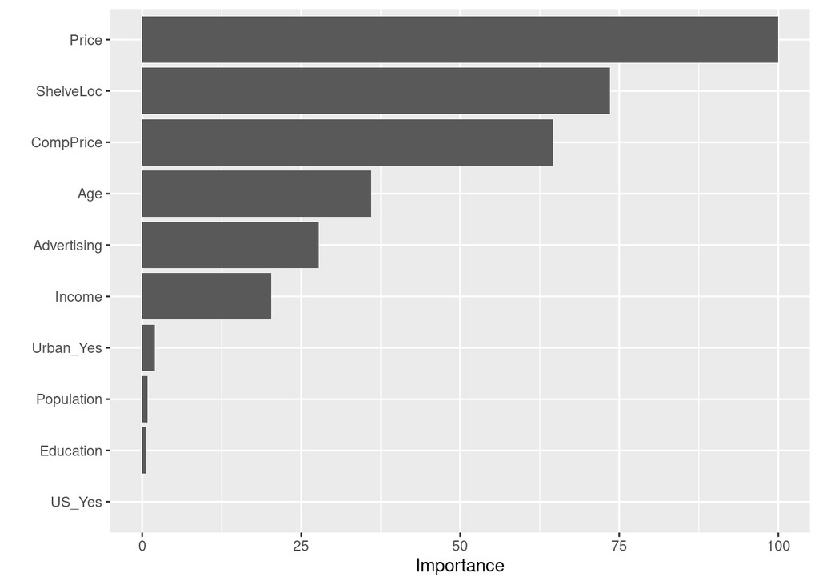

```r
vip(lm_cv, method = "model")
```

## Question 3

Suppose we collect data for a group of students in a statistics class with variables $X$ = number of hours studied per week, and $Y$ = received an A(1) or not(0). We fit a logistic regression model and produce estimated coefficients $\hat{\beta}_0 = -2.3$, and $\hat{\beta}_1=0.05$. For the following questions, show as much work as possible to receive full credit.

1. Estimate the probability that a student who studies 40 hours per week gets an A in the class. [Hint: The function `exp(a)` calculates $e^a$.]

```
We have the coefficients and X = 40. So the equation is:

k = -2.3 +0.05(40) = -0.3

Then, p̂ (k) when k = -0.3 is calculated using r. We then get 0.4255575.

Then, a student who studies 40 hours has a probabiity of 0.4255575 of getting an A in the class.
```

```r
(exp(-0.3))/(1+exp(-0.3))
```

```
## [1] 0.4255575
```

2. Estimate the probability that a student who studies 40 hours per week does not get an A in the class.

```
The test data is the same as the last question. The response variable is the same. And since there are only 2 options, Yes or No, in the response, the probability of getting each result has the sum of 1. In other words, p1 + p2 = 1. Then, the probability of the same student not getting an A would be 1 - the probability of that student getting an A. That would be 0.5744425.
```

```r
1-(exp(-0.3))/(1+exp(-0.3))
```

```
## [1] 0.5744425
```

3. Based on a threshold of 0.5 and your answers from (a) and (b), what would be the predicted response ($\hat{y}$) for a student who studies 40 hours per week? Your answer should be in terms of the class labels: receives an A(1) or not(0).

```
The predicted response for a student who studies 40 hours per week would be 0.
```

```r
threshold <- 0.5
logreg_class_preds <- factor(ifelse(0.4255575 > threshold, "1", "0"))
logreg_class_preds
```

```
## [1] 0
## Levels: 0
```

## Question 4

For this question, you will work with the **scheduling.rds** dataset. Load the dataset using the following code.

```r
scheduling <- readRDS("scheduling.rds")
```

These data contain information on jobs in a high performance computing environment. The variables in the dataset are,

- `Protocol` - the type of computation
- `Compounds` - the number of data points for each jobs
- `InputFields` - the number of characteristics being estimated
- `Iterations` - maximum number of iterations for the computations
- `NumPending` - the number of other jobs pending at the time of launch
- `Hour` - decimal hour of day for launch time
- `Day` - day of launch time
- `Class` - execution speed of the job (‘fast’, ‘slow’)

The task is to build a classifier to predict `Class` based on the rest of the variables in the dataset.

Compare the performance (in terms of **Accuracy**) of the following two models:

- Logistic regression;
- $K$-NN classifier with optimal $K$ chosen by CV. Consider the grid of possible $K$ values given below.

**Perform the following tasks.**

- Investigate the dataset and complete any necessary tasks. **Write a brief description of your findings.**

```r
glimpse(scheduling)
```

```
## Rows: 2,120
## Columns: 8
## $ Protocol    <fct> E, E, E, E, E, E, E, E, E, E, E, E, E, E, E, E, E, A, A, A…
## $ Compounds   <dbl> 997, 1501, 244, 308, 303, 300, 302, 498, 563, 790, 775, 78…
## $ InputFields <dbl> 137, 137, 210, 289, 299, 299, 299, 141, 155, 779, 784, 780…
## $ Iterations  <dbl> 20, 20, 20, 20, 20, 20, 20, 20, 20, 20, 20, 20, 20, 20, 20…
## $ NumPending  <dbl> 0, 0, 0, 0, 0, 0, 0, 0, 0, 0, 0, 0, 0, 0, 0, 0, 0, 3340, 1…
## $ Hour        <dbl> 14.00000, 14.10000, 15.91667, 15.50000, 16.00000, 14.50000…
## $ Day         <fct> Tue, Tue, Fri, Fri, Fri, Fri, Fri, Tue, Mon, Wed, Fri, Fri…
## $ Class       <fct> fast, fast, fast, fast, fast, fast, fast, fast, fast, slow…
```

```r
sum(is.na(scheduling))
```

```
## [1] 0
```

```r
summary(scheduling)
```

```
##     Protocol     Compounds        InputFields        Iterations
##  O      :556   Min.   :   20.0   Min.   :   10.0   Min.   : 10.00
##  M      :385   1st Qu.:  152.0   1st Qu.:  192.8   1st Qu.: 20.00
##  J      :315   Median :  305.0   Median :  463.0   Median : 20.00
##  H      :260   Mean   :  744.9   Mean   : 1323.2   Mean   : 37.68
##  N      :235   3rd Qu.:  601.5   3rd Qu.:  823.8   3rd Qu.: 20.00
##  F      : 90   Max.   :14103.0   Max.   :56671.0   Max.   :200.00
##  (Other):279
##    NumPending           Hour           Day       Class
##  Min.   :   0.00   Min.   : 0.01667   Mon:321   slow: 773
##  1st Qu.:   0.00   1st Qu.:11.18333   Tue:477   fast:1347
##  Median :   0.00   Median :14.13333   Wed:441
##  Mean   :  94.54   Mean   :13.73123   Thu:349
##  3rd Qu.:   3.00   3rd Qu.:16.63333   Fri:443
##  Max.   :5547.00   Max.   :23.80000   Sat: 17
##                                       Sun: 72
```

```r
nearZeroVar(scheduling, saveMetrics = TRUE)
```

```
##             freqRatio percentUnique zeroVar   nzv
## Protocol     1.444156    0.66037736   FALSE FALSE
## Compounds    1.000000   35.18867925   FALSE FALSE
## InputFields  1.041667   49.43396226   FALSE FALSE
## Iterations  11.478571    0.51886792   FALSE FALSE
## NumPending  19.283784   12.78301887   FALSE FALSE
## Hour         1.083333   35.99056604   FALSE FALSE
## Day          1.076749    0.33018868   FALSE FALSE
## Class        1.742561    0.09433962   FALSE FALSE
```

```
categorical features: Protocol, Day. (They are both nominal)
numerical features: Compounds, InputFields, Iterations, NumPending, Hour

There is no NA value.

It seems that some of the values in Protocol can be lumped.

The dataset has no zv or nzv features.
```

- Split the data into training and test sets (80-20).

```r
# write your R code here
set.seed(666)

train_index <- createDataPartition(scheduling$Class, p = 0.8, list = FALSE)

scheduling_train <- scheduling[train_index,]    # training set

scheduling_test <- scheduling[-train_index,]    # test set

nearZeroVar(scheduling_train, saveMetrics = TRUE)
```

```
##             freqRatio percentUnique zeroVar   nzv
## Protocol     1.483553     0.8249853   FALSE FALSE
## Compounds    1.153846    40.3653506   FALSE FALSE
## InputFields  1.166667    54.0365351   FALSE FALSE
## Iterations  10.446281     0.6482027   FALSE FALSE
## NumPending  19.338983    13.7890395   FALSE FALSE
## Hour         1.052632    41.5439010   FALSE FALSE
## Day          1.056338     0.4124926   FALSE FALSE
## Class        1.741519     0.1178550   FALSE FALSE
```

```r
scheduling_train %>% count(Protocol) %>% arrange(n)
```

```
##    Protocol   n
## 1         D   1
## 2         K   1
## 3         E  13
## 4         I  29
## 5         G  36
## 6         L  43
## 7         C  49
## 8         A  51
## 9         F  70
## 10        H 193
## 11        N 194
## 12        J 262
## 13        M 304
## 14        O 451
```

- Perform required data preprocessing and create the blueprint. If using `step_dummy()`, set `one_hot = FALSE`. Prepare the blueprint on the training data. Obtain the modified training and test datasets. **Provide brief explanations/reasonings of your feature engineering steps.**

```r
# write your R code here
set.seed(666)

scheduling_recipe <- recipe(Class ~ ., data = scheduling_train)  # set up recipe

scheduling_recipe$var_info   # check recipe
```

```
## # A tibble: 8 × 4
##   variable    type      role      source
##   <chr>       <list>    <chr>     <chr>
## 1 Protocol    <chr [3]> predictor original
## 2 Compounds   <chr [2]> predictor original
## 3 InputFields <chr [2]> predictor original
## 4 Iterations  <chr [2]> predictor original
## 5 NumPending  <chr [2]> predictor original
## 6 Hour        <chr [2]> predictor original
## 7 Day         <chr [3]> predictor original
## 8 Class       <chr [3]> outcome   original
```

```r
blueprint <- scheduling_recipe %>%
  step_center(all_numeric()) %>%
  step_scale(all_numeric()) %>%
  step_other(Protocol, threshold = 0.01, other = "other")  %>%
  step_dummy(all_nominal(), -all_outcomes(), one_hot = FALSE)

prepare <- prep(blueprint, data = scheduling_train)

baked_train <- bake(prepare, new_data = scheduling_train)

baked_test <- bake(prepare, new_data = scheduling_test)

summary(baked_train)
```

```
##    Compounds         InputFields        Iterations        NumPending
##  Min.   :-0.53186   Min.   :-0.3272   Min.   :-0.6081   Min.   :-0.2022
##  1st Qu.:-0.43692   1st Qu.:-0.2847   1st Qu.:-0.3939   1st Qu.:-0.2022
##  Median :-0.32386   Median :-0.2200   Median :-0.3939   Median :-0.2022
##  Mean   : 0.00000   Mean   : 0.0000   Mean   : 0.0000   Mean   : 0.0000
##  3rd Qu.:-0.06078   3rd Qu.:-0.1320   3rd Qu.:-0.3939   3rd Qu.:-0.1957
##  Max.   : 9.67465   Max.   :13.0513   Max.   : 3.4623   Max.   :11.8209
##       Hour          Class        Protocol_C        Protocol_F
##  Min.   :-3.3644   slow: 619   Min.   :0.00000   Min.   :0.00000
##  1st Qu.:-0.6345   fast:1078   1st Qu.:0.00000   1st Qu.:0.00000
##  Median : 0.1011               Median :0.00000   Median :0.00000
##  Mean   : 0.0000               Mean   :0.02887   Mean   :0.04125
##  3rd Qu.: 0.7223               3rd Qu.:0.00000   3rd Qu.:0.00000
##  Max.   : 2.4673               Max.   :1.00000   Max.   :1.00000
##    Protocol_G        Protocol_H       Protocol_I        Protocol_J
##  Min.   :0.00000   Min.   :0.0000   Min.   :0.00000   Min.   :0.0000
##  1st Qu.:0.00000   1st Qu.:0.0000   1st Qu.:0.00000   1st Qu.:0.0000
##  Median :0.00000   Median :0.0000   Median :0.00000   Median :0.0000
##  Mean   :0.02121   Mean   :0.1137   Mean   :0.01709   Mean   :0.1544
##  3rd Qu.:0.00000   3rd Qu.:0.0000   3rd Qu.:0.00000   3rd Qu.:0.0000
##  Max.   :1.00000   Max.   :1.0000   Max.   :1.00000   Max.   :1.0000
##    Protocol_L        Protocol_M       Protocol_N       Protocol_O
##  Min.   :0.00000   Min.   :0.0000   Min.   :0.0000   Min.   :0.0000
##  1st Qu.:0.00000   1st Qu.:0.0000   1st Qu.:0.0000   1st Qu.:0.0000
##  Median :0.00000   Median :0.0000   Median :0.0000   Median :0.0000
##  Mean   :0.02534   Mean   :0.1791   Mean   :0.1143   Mean   :0.2658
##  3rd Qu.:0.00000   3rd Qu.:0.0000   3rd Qu.:0.0000   3rd Qu.:1.0000
##  Max.   :1.00000   Max.   :1.0000   Max.   :1.0000   Max.   :1.0000
##  Protocol_other        Day_Tue         Day_Wed          Day_Thu
##  Min.   :0.000000   Min.   :0.000   Min.   :0.0000   Min.   :0.0000
##  1st Qu.:0.000000   1st Qu.:0.000   1st Qu.:0.0000   1st Qu.:0.0000
##  Median :0.000000   Median :0.000   Median :0.0000   Median :0.0000
##  Mean   :0.008839   Mean   :0.221   Mean   :0.2092   Mean   :0.1697
##  3rd Qu.:0.000000   3rd Qu.:0.000   3rd Qu.:0.0000   3rd Qu.:0.0000
##  Max.   :1.000000   Max.   :1.000   Max.   :1.0000   Max.   :1.0000
##     Day_Fri          Day_Sat            Day_Sun
##  Min.   :0.0000   Min.   :0.000000   Min.   :0.00000
##  1st Qu.:0.0000   1st Qu.:0.000000   1st Qu.:0.00000
##  Median :0.0000   Median :0.000000   Median :0.00000
##  Mean   :0.2057   Mean   :0.008839   Mean   :0.03241
##  3rd Qu.:0.0000   3rd Qu.:0.000000   3rd Qu.:0.00000
##  Max.   :1.0000   Max.   :1.000000   Max.   :1.00000
```

```r
summary(baked_test)
```

```
##    Compounds         InputFields         Iterations         NumPending
##  Min.   :-0.53186   Min.   :-0.32723   Min.   :-0.60813   Min.   :-0.20223
##  1st Qu.:-0.43329   1st Qu.:-0.28261   1st Qu.:-0.39390   1st Qu.:-0.20223
##  Median :-0.32893   Median :-0.22122   Median :-0.39390   Median :-0.20223
##  Mean   :-0.03241   Mean   :-0.08604   Mean   :-0.07635   Mean   : 0.01341
##  3rd Qu.:-0.14231   3rd Qu.:-0.14342   3rd Qu.:-0.39390   3rd Qu.:-0.19465
##  Max.   : 6.63582   Max.   : 7.56184   Max.   : 3.46230   Max.   :11.82093
##       Hour            Class       Protocol_C        Protocol_F
##  Min.   :-3.348044   slow:154   Min.   :0.00000   Min.   :0.00000
##  1st Qu.:-0.593643   fast:269   1st Qu.:0.00000   1st Qu.:0.00000
##  Median : 0.084741              Median :0.00000   Median :0.00000
##  Mean   :-0.007987              Mean   :0.02128   Mean   :0.04728
##  3rd Qu.: 0.648698              3rd Qu.:0.00000   3rd Qu.:0.00000
##  Max.   : 2.226145              Max.   :1.00000   Max.   :1.00000
##    Protocol_G        Protocol_H       Protocol_I         Protocol_J
##  Min.   :0.00000   Min.   :0.0000   Min.   :0.000000   Min.   :0.0000
##  1st Qu.:0.00000   1st Qu.:0.0000   1st Qu.:0.000000   1st Qu.:0.0000
##  Median :0.00000   Median :0.0000   Median :0.000000   Median :0.0000
##  Mean   :0.04728   Mean   :0.1584   Mean   :0.007092   Mean   :0.1253
##  3rd Qu.:0.00000   3rd Qu.:0.0000   3rd Qu.:0.000000   3rd Qu.:0.0000
##  Max.   :1.00000   Max.   :1.0000   Max.   :1.000000   Max.   :1.0000
##    Protocol_L        Protocol_M       Protocol_N        Protocol_O
##  Min.   :0.00000   Min.   :0.0000   Min.   :0.00000   Min.   :0.0000
##  1st Qu.:0.00000   1st Qu.:0.0000   1st Qu.:0.00000   1st Qu.:0.0000
##  Median :0.00000   Median :0.0000   Median :0.00000   Median :0.0000
##  Mean   :0.01891   Mean   :0.1915   Mean   :0.09693   Mean   :0.2482
##  3rd Qu.:0.00000   3rd Qu.:0.0000   3rd Qu.:0.00000   3rd Qu.:0.0000
##  Max.   :1.00000   Max.   :1.0000   Max.   :1.00000   Max.   :1.0000
##  Protocol_other        Day_Tue          Day_Wed          Day_Thu
##  Min.   :0.000000   Min.   :0.0000   Min.   :0.0000   Min.   :0.0000
##  1st Qu.:0.000000   1st Qu.:0.0000   1st Qu.:0.0000   1st Qu.:0.0000
##  Median :0.000000   Median :0.0000   Median :0.0000   Median :0.0000
##  Mean   :0.009456   Mean   :0.2411   Mean   :0.2033   Mean   :0.1442
##  3rd Qu.:0.000000   3rd Qu.:0.0000   3rd Qu.:0.0000   3rd Qu.:0.0000
##  Max.   :1.000000   Max.   :1.0000   Max.   :1.0000   Max.   :1.0000
##     Day_Fri          Day_Sat            Day_Sun
##  Min.   :0.0000   Min.   :0.000000   Min.   :0.00000
##  1st Qu.:0.0000   1st Qu.:0.000000   1st Qu.:0.00000
##  Median :0.0000   Median :0.000000   Median :0.00000
##  Mean   :0.2222   Mean   :0.004728   Mean   :0.04019
##  3rd Qu.:0.0000   3rd Qu.:0.000000   3rd Qu.:0.00000
##  Max.   :1.0000   Max.   :1.000000   Max.   :1.00000
```

```
There are no NA values so we do not need to impute.

There are no ordinal variable, so we do not have to use step_integer.

We scale all numerical features.

The frequencies of some of the values in Protocal is quite low, so we lump them together into "other".

Then, we use step_dummy to convert data in all nominal features.
```

- Implement 5-fold CV repeated 5 times for each of the models above.

```r
# write your R code here
set.seed(666)

cv_specs <- trainControl(method = "repeatedcv", number = 5, repeats = 5)

logistic_cv <- train(blueprint,
                data = scheduling_train,
                method = "glm",
                family = "binomial",
                trControl = cv_specs,
                metric = "Accuracy")

k_grid <- expand.grid(k = seq(1, 101, by = 10))

knn_cv <- train(blueprint,
                data = scheduling_train,
                method = "knn",
                trControl = cv_specs,
                tuneGrid = k_grid,
                metric = "Accuracy")
```

- Report the CV Accuracy for each model. Report the optimal value of $K$ for the $K$-NN classifier. Which model performs better in this situation?

```r
logistic_cv
```

```
## Generalized Linear Model
##
## 1697 samples
##    7 predictor
##    2 classes: 'slow', 'fast'
##
## Recipe steps: center, scale, other, dummy
## Resampling: Cross-Validated (5 fold, repeated 5 times)
## Summary of sample sizes: 1359, 1357, 1358, 1357, 1357, 1358, ...
## Resampling results:
##
##   Accuracy   Kappa
##   0.7933858  0.5226833
```

```r
max(knn_cv$results$Accuracy)
```

```
## [1] 0.7932772
```

```r
knn_cv$bestTune$k
```

```
## [1] 1
```

```
The accuracy of the logistic regression model is 0.7933858.
The accuracy of the knn model is 0.7932772.
The logistic regression model has a higher accuracy, so it performs better here.
The optimal value of k in knn is k = 1.
```

```r
final_model <- glm(Class ~ ., data = baked_train, family = binomial)

final_model_prob_preds <- predict(object = final_model, newdata = baked_test, type = "response")   # obtain probability predictions

threshold <- 0.5   # set threshold

final_model_class_preds <- factor(ifelse(final_model_prob_preds > threshold, "fast", "slow"))   # obtain class predictions

# confusion matrix

confusionMatrix(data = relevel(final_model_class_preds, ref = "fast"),
                reference = relevel(baked_test$Class, ref = "fast"))
```

```
## Confusion Matrix and Statistics
##
##           Reference
## Prediction fast slow
##       fast  255   70
##       slow   14   84
##
##                Accuracy : 0.8014
##                  95% CI : (0.7602, 0.8384)
##     No Information Rate : 0.6359
##     P-Value [Acc > NIR] : 9.745e-14
##
##                   Kappa : 0.535
##
##  Mcnemar's Test P-Value : 1.961e-09
##
##             Sensitivity : 0.9480
##             Specificity : 0.5455
##          Pos Pred Value : 0.7846
##          Neg Pred Value : 0.8571
##              Prevalence : 0.6359
##          Detection Rate : 0.6028
##    Detection Prevalence : 0.7683
##       Balanced Accuracy : 0.7467
##
##        'Positive' Class : fast
##
```

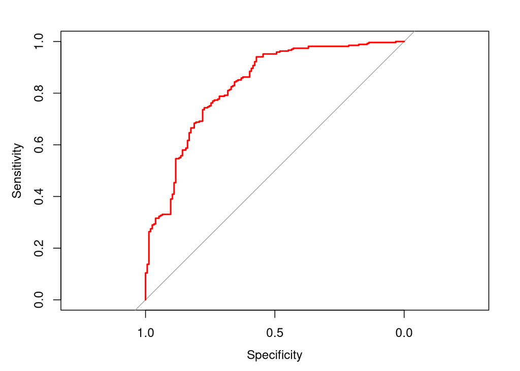

```r
roc_object <- roc(response = baked_test$Class, predictor = final_model_prob_preds)
# plot ROC curve
plot(roc_object, col = "red")
```

## Question 5

Suppose that we take a data set, divide it into equally-sized training and test sets, and then try out two different classification procedures. First, we use logistic regression and get an error rate of 23% on the training data and 27% on the test data. Next, we use 1-nearest neighbors (i.e. $K = 1$) and get an average error rate (averaged over both test and training data sets) of 18%. Based on these results, which method should we prefer to use for classification of new (unseen) observations? Explain your answer.

```
We should use the logistic regression.

Because k = 1, for every test data point, there is only going to be 1 predicted response that corresponds to 1 nearest training data point. Since our data set is divided into equally-sized training and test sets, every test data point will simply find itself in the training data. Then, the test error would be 0%. That would mean that since the average error rate is 18%, the training error would be 36%. This is higher than the training error of the logistic regression procedure.
```

## Question 6

Given below is a confusion matrix for a classifier evaluated on a test dataset. The class of interest is `A`, that is `A` is the positive class.

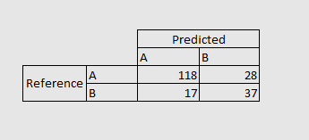

For the following questions, show your work to receive full credit.

1. How many observations were there in the test dataset?

```
There are 118 + 28 + 17 + 37 = 200 observations in the dataset.
```

2. Report the accuracy of the classifier.

```
The accuracy is (118+37)/(118+28+17+37) = 0.775
```

3. Report the recall and precision of the classifier.

[output not shown]

## Question 7

What are the advantages and disadvantages of a very flexible (versus a less flexible) approach for regression or classification? Under what circumstances might a more flexible approach be preferred to a less flexible approach? When might a less flexible approach be preferred? Explain.

```
Advantages: it has a lower bias than a less flexible approach. It can also fit non-linear problems better.

Disadvantages: it requires a very large number of features. It also has a higher risk of overfitting. Finally, it has a higher variance.

A more flexible approach would be preferred to a less flexible approach when we want to make predictions as accurate as possible without worrying about the interpretability of the model.

A less flexible approach would be preferred to a more flexible approach when we are more interested in the interpretability of the model and not in making extremely accurate predictions as much.
```